# Investigating Influenza Susceptibility by Population and Sex

UPGG Computational Bootcamp Final Project

Angela Jones

# The Dataset

This dataset was generated by the Ko lab through a new single-cell RNAseq protocol called **scHi-HOST**. In scHi-HOST, human lymphoblastoid cell lines from 48 individuals (24 females, 24 males) across three distinct populations are infected with influenza A virus. Single-cell RNA-seq of the infected cells and downstream bioinformatics allows for the deconvolution of the viral and host RNA to create net flu phenotypes per individual (*e.g.* median flu reads). This protocol is a recent improvement on the previously published [Hi-HOST](http://h2p2.oit.duke.edu/H2P2Home/) system.

## Load and investigate dataset through `glimpse`

```
## Rows: 48
## Columns: 31
## $ `#FAM_ID`                       <chr> "HG00107", "HG00108", "HG00109", "HG00…
## $ IID_ID                          <lgl> NA, NA, NA, NA, NA, NA, NA, NA, NA, NA…
## $ FAT_ID                          <lgl> NA, NA, NA, NA, NA, NA, NA, NA, NA, NA…
## $ MOT_ID                          <lgl> NA, NA, NA, NA, NA, NA, NA, NA, NA, NA…
## $ Sex                             <chr> "Male", "Male", "Male", "Female", "Mal…
## $ Population                      <chr> "BRITISH", "BRITISH", "BRITISH", "BRIT…
## $ TotalCells                      <dbl> 472, 418, 561, 478, 526, 534, 516, 463…
## $ MeanPercentViralReads           <dbl> 0.7183562, 0.9911066, 1.1260564, 0.238…
## $ log2MeanPercentViralReads       <dbl> -0.47722862, -0.01288783, 0.17127915, …
## $ MeanNormViralReads              <dbl> 279.89182, 386.16304, 438.74329, 92.74…
## $ log2MeanNormViralReads          <dbl> 8.128725, 8.593066, 8.777233, 6.535157…
## $ MedianNormViralReads            <dbl> 8.347149, 7.266952, 8.902531, 7.650778…
## $ log2MedianNormViralReads        <dbl> 3.061283, 2.861350, 3.154215, 2.935606…
```

[output cut: 18 more lines]

## Remove extra columns from dataset and tidy ‘Population’ column

```
## Rows: 48
## Columns: 28
## $ FAM_ID                          <chr> "HG00107", "HG00108", "HG00109", "HG00…
## $ Sex                             <chr> "Male", "Male", "Male", "Female", "Mal…
## $ Population                      <chr> "British", "British", "British", "Brit…
## $ TotalCells                      <dbl> 472, 418, 561, 478, 526, 534, 516, 463…
## $ MeanPercentViralReads           <dbl> 0.7183562, 0.9911066, 1.1260564, 0.238…
## $ log2MeanPercentViralReads       <dbl> -0.47722862, -0.01288783, 0.17127915, …
## $ MeanNormViralReads              <dbl> 279.89182, 386.16304, 438.74329, 92.74…
## $ log2MeanNormViralReads          <dbl> 8.128725, 8.593066, 8.777233, 6.535157…
## $ MedianNormViralReads            <dbl> 8.347149, 7.266952, 8.902531, 7.650778…
## $ log2MedianNormViralReads        <dbl> 3.061283, 2.861350, 3.154215, 2.935606…
## $ PercentPB2                      <dbl> 11.665885, 10.427089, 10.931688, 11.37…
## $ PercentPB1                      <dbl> 11.898321, 12.476975, 9.838366, 12.080…
## $ PercentPA                       <dbl> 2.395715, 2.071720, 2.700855, 2.247922…
## $ PercentHA                       <dbl> 16.67453, 17.94618, 17.61356, 19.87395…
## $ PercentNP                       <dbl> 35.02314, 35.25111, 37.26254, 34.46677…
## $ PercentNA                       <dbl> 14.08064, 14.00031, 13.54952, 13.71516…
## $ PercentM                        <dbl> 1.5100527, 1.3404382, 1.4917763, 1.431…
## $ PercentNS                       <dbl> 6.751710, 6.486172, 6.611702, 4.806871…
## $ log2PercentPB2                  <dbl> 3.544224, 3.382264, 3.450444, 3.508071…
## $ log2PercentPB1                  <dbl> 3.572686, 3.641196, 3.298419, 3.594627…
## $ log2PercentPA                   <dbl> 1.2604566, 1.0508290, 1.4334160, 1.168…
## $ log2PercentHA                   <dbl> 4.059574, 4.165605, 4.138615, 4.312807…
## $ log2PercentNP                   <dbl> 5.130236, 5.139597, 5.219654, 5.107134…
## $ log2PercentNA                   <dbl> 3.815641, 3.807387, 3.760169, 3.777700…
## $ log2PercentM                    <dbl> 0.59459892, 0.42270467, 0.57703117, 0.…
## $ log2PercentNS                   <dbl> 2.755253, 2.697367, 2.725022, 2.265098…
## $ PercentCellsWithAllSegments     <dbl> 4.449153, 6.459330, 5.169340, 1.255230…
## $ log2PercentCellsWithAllSegments <dbl> 2.1535306, 2.6913846, 2.3699802, 0.327…
```

# Analyze Dataset

First, investigate if different individuals have more flu reads per cell than others. We can even start to compare by population here.

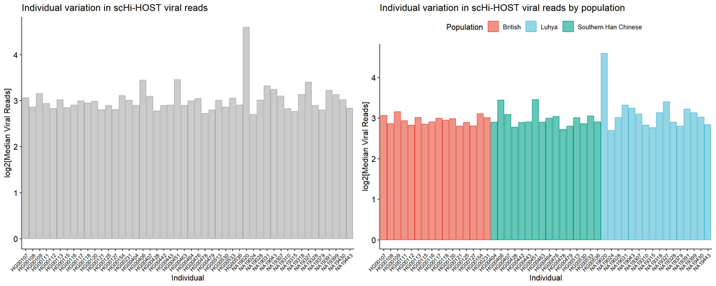

It looks like there is a lot of variation between individuals and maybe trends by population, but that’s difficult to visualize with the above plots. Another method of visualization will be helpful.

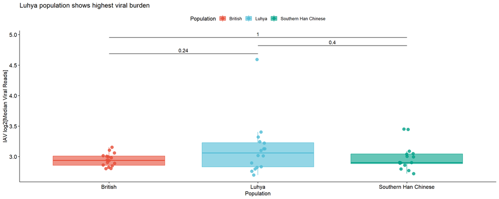

The above plot is much more useful. From this plot we can see that the [Luhya](https://en.wikipedia.org/wiki/Luhya_people) population (in Kenya) appears to more susceptible to flu infection than the British and Southern Han Chinese populations.

While population differences are useful to know, my research is focused on sex differences in flu susceptibility and how that differs between populations.

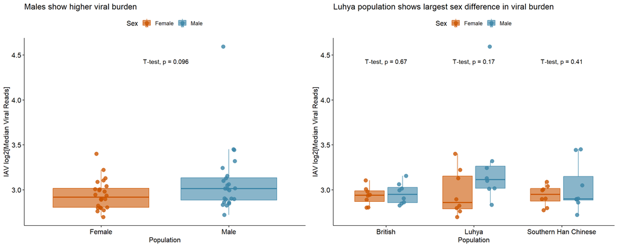

# Conclusions

The above analyses show that there are individual, population, and sex differences in influenza A susceptibility. The Luhya population appears to be more susceptible to infection than the other populations, although this difference is not statistically significant[^1]. When sex differences are considered, there is a trend towards males being more susceptible to flu infection than females[^2]. Sex differences within each population are less robust, but the Luhya population shows the strongest sex difference in susceptibility with higher flu burden in males than females[^3].

# Future Directions

# Acknowledgements

I would like to thank Ben Schott and Liuyang Wang for generating this dataset, as well as the wonderful instructores for this bootcamp. Lastly, thank you all for the fun and collaborative experience of this module! Live long and prosper!

[^1]: Student’s T-Test
[^2]: p = 0.096, Student’s T-Test
[^3]: p = 0.17, Student’s T-Test